# Внешний курс. Блок 2

Основы информационной безопасности

Краснова К. Г., НКАбд-03-24

Российский университет дружбы народов, Москва, Россия

17 февраля 2026

# Цель работы

Пройти второй блок курса “Основы кибербезопасности”

# Выполнение блока 2: Защита ПК/Телефона

## Шифрование диска

Шифрование диска — технология защиты информации, переводящая данные на диске в нечитаемый код, который нелегальный пользователь не сможет легко расшифровать. Соответственно, можно (рис. [-@fig:001]).

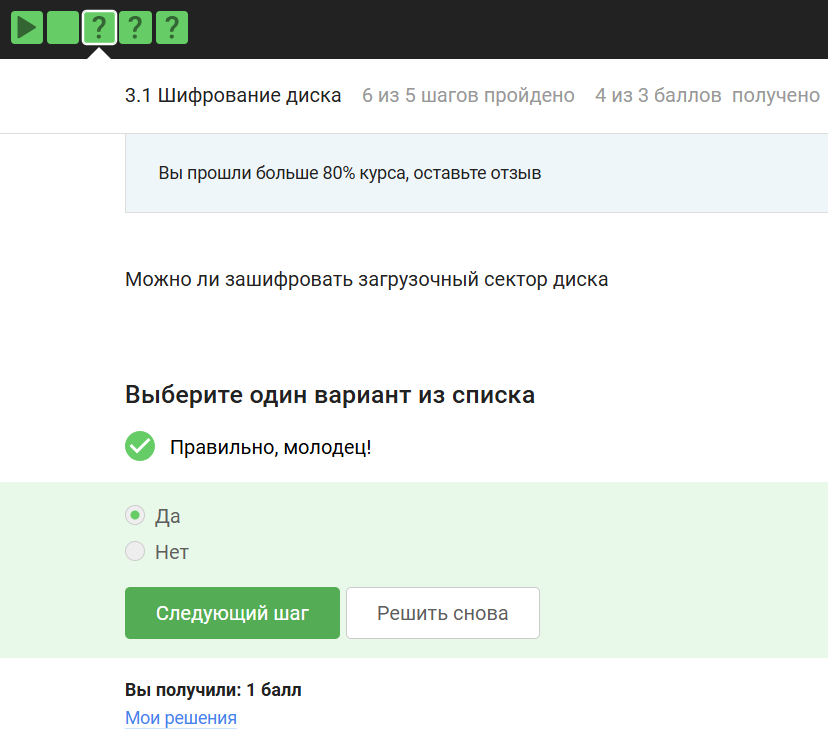

Вопрос 3.1.1

## Шифрование диска

Шифрование диска основано на симметричном шифровании (рис. [-@fig:002]).

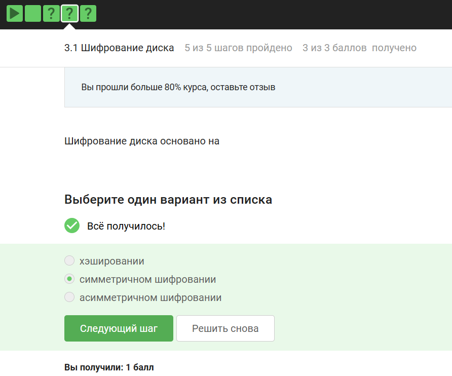

Вопрос 3.1.2

## Шифрование диска

Отмечены программы, с помощью которых можно зашифровать жетский диск (рис. [-@fig:003]).

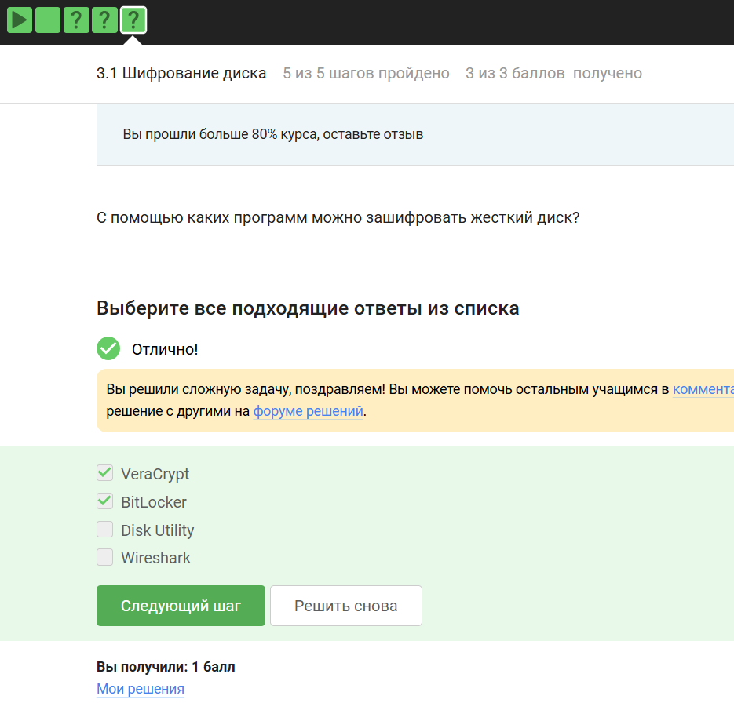

Вопрос 3.1.3

## Пароли

Стойкий пароль - тот, который тяжлее подобрать, он должен быть со спец. символами и длинный (рис. [-@fig:004]).

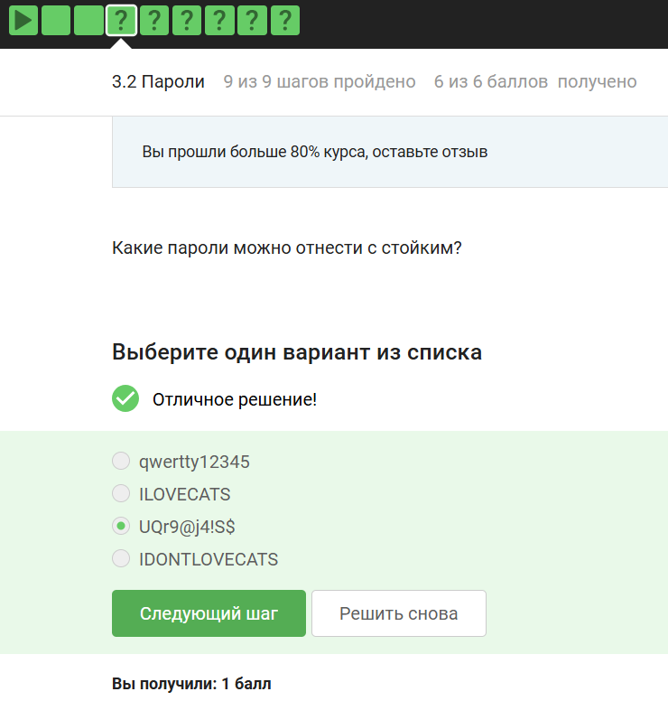

Вопрос 3.2.1

## Пароли

Все варианты, кроме менеджера паролей, совершенно не надежные (рис. [-@fig:005]).

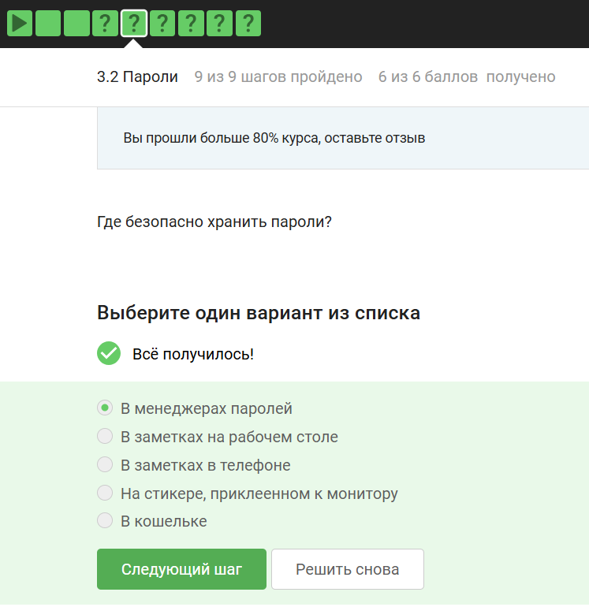

Вопрос 3.2.2

## Пароли

Капча нужна для проверки на то, что за экраном “не робот”(рис. [-@fig:006]).

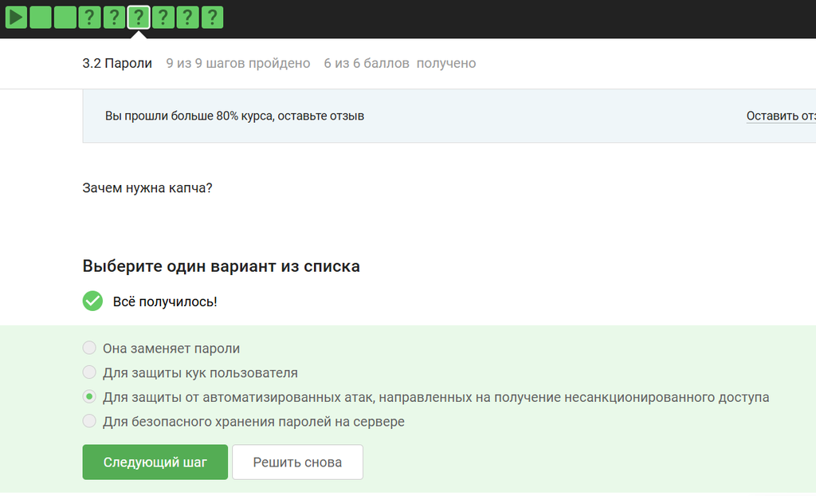

Вопрос 3.2.3

## Пароли

Опасно хранить пароли в открытом виде, поэтому хранят их хэши (рис. [-@fig:007]).

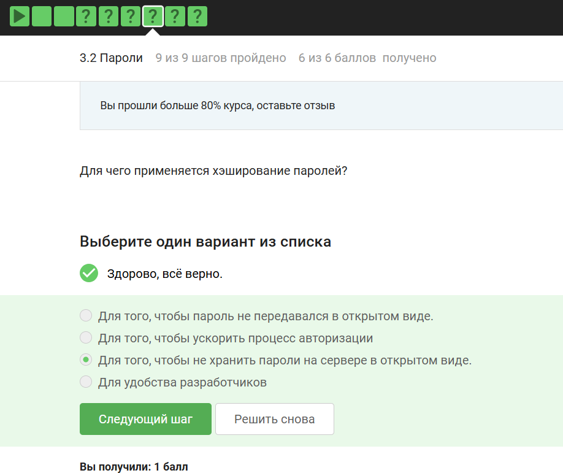

Вопрос 3.2.4

## Пароли

Соль не поможет (рис. [-@fig:008]).

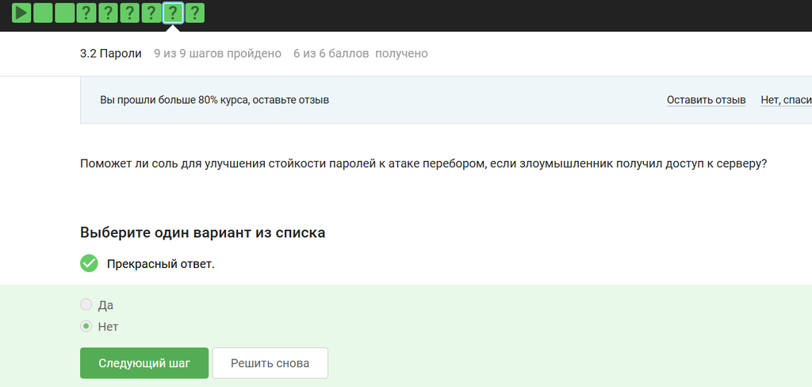

Вопрос 3.2.5

## Пароли

Все приведенные меры защищают от утечек данных (рис. [-@fig:009]).

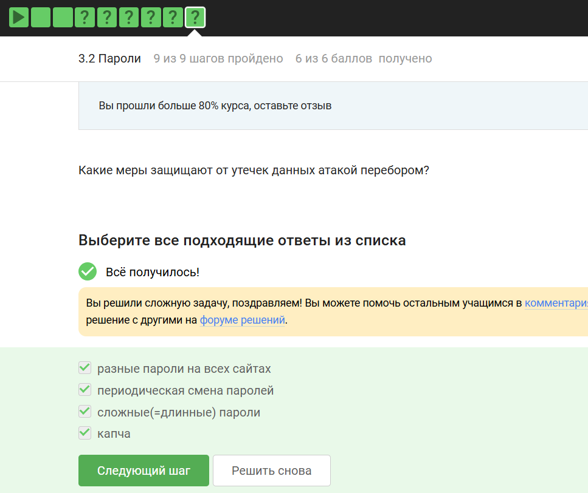

НВопрос 3.2.6

## Фишинг

Фишинговые ссылки очень похожи на ссылки известных сервисов, но с некоторыми отличиями (рис. [-@fig:010]).

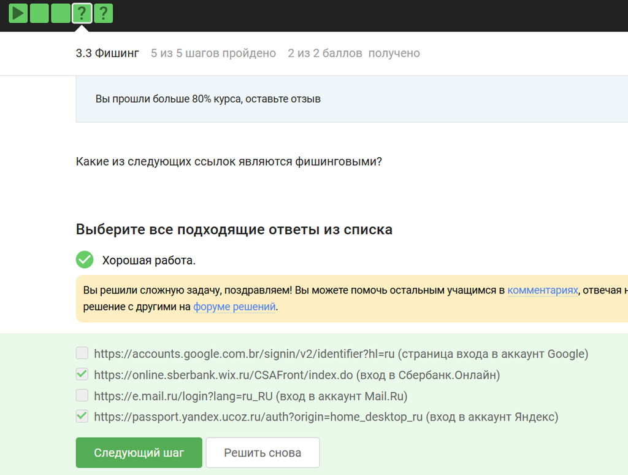

Вопрос 3.3.1

## Фишинг

Да, может, например, если пользователя со знакомым адресом взломали (рис. [-@fig:011]).

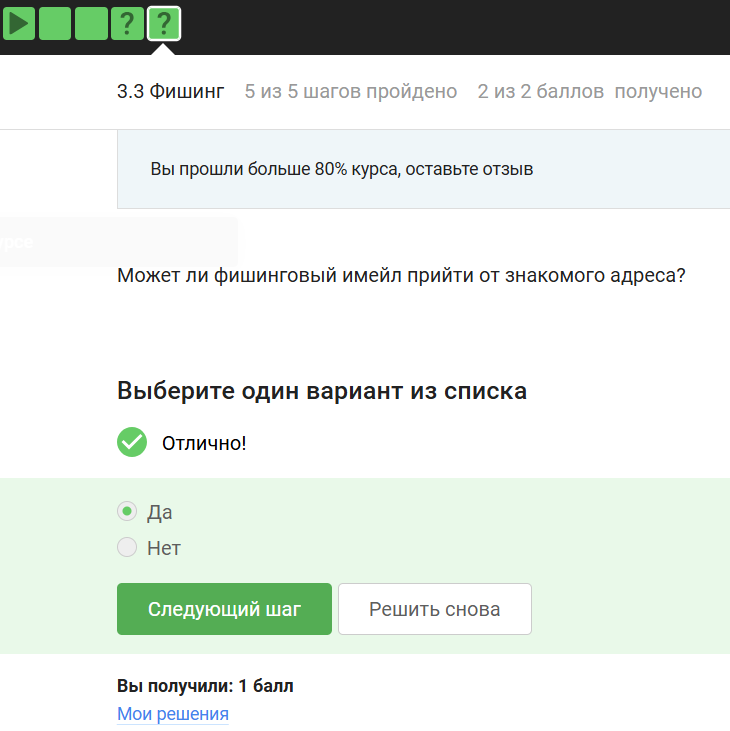

Вопрос 3.3.2

## Вирусы. Примеры

Ответ дан в соответствии с определением (рис. [-@fig:012]).

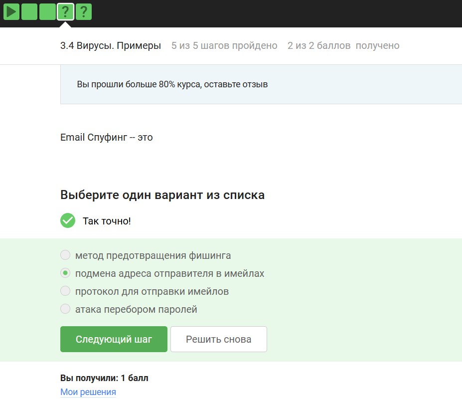

Вопрос 3.4.1

## Вирусы. Примеры

Троян маскируется под обычную программу (рис. [-@fig:013]).

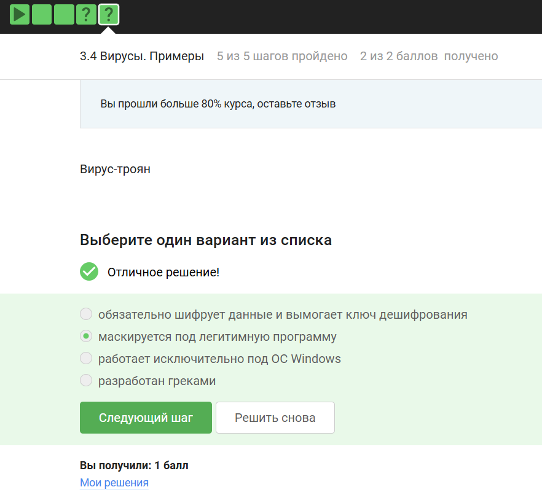

Вопрос 3.4.2

## Безопасность мессенджеров

При установке первого сообщения отправителем формируется ключ шифрования (рис. [-@fig:014]).

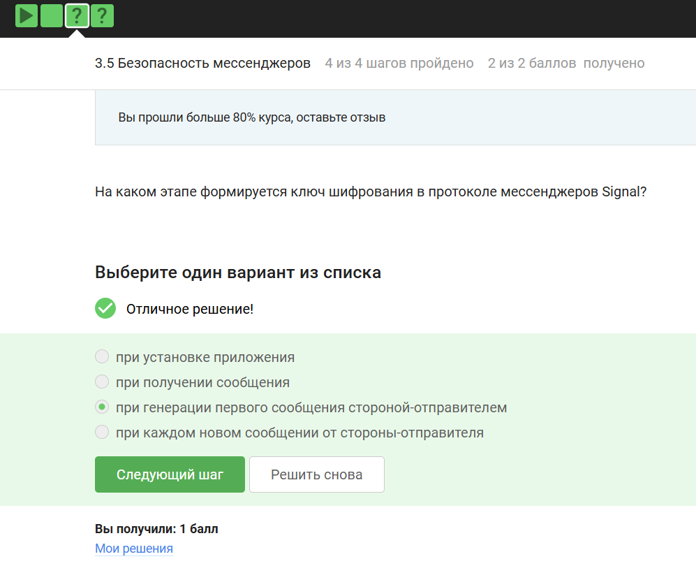

Вопрос 3.5.1

## Безопасность мессенджеров

Суть сквозного шифрования состоит в том, что сообзения передаются по узлам связи в зашифрованном виде (рис. [-@fig:015]).

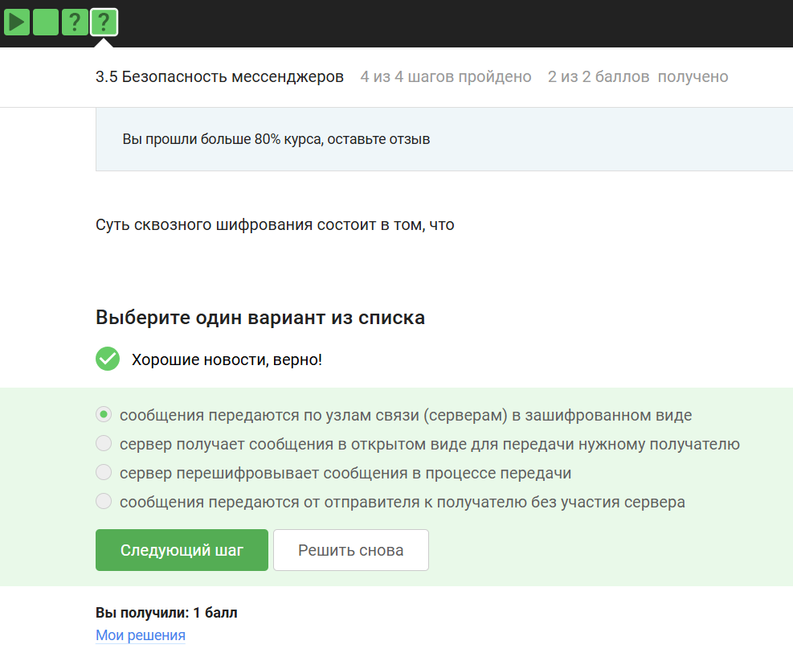

Вопрос 3.5.2

# Выводы

Был пройден второй блок курса “Основы кибербезопасности”, изучены правила хранения паролей и основная информация о вирусах